# TargetCNV-ML: Reporte de Transferencia Filogenética y Concordancia CNV

Validación Inter-Especie según Escala del Genoma, Concordancia por Ortogrupo y Calibración del Umbral de Cobertura

Author

TargetCNV-ML

Published

November 1, 2026

## 1 Diseño de Validación Filogenética según Escala Estructural del Genoma

La evaluación de transferibilidad aplica sin reajuste paramétrico los clasificadores entrenados en *Solanum torvum* sobre especies receptoras con distinta continuidad estructural de ensamblaje:

- **Escala cromosómica (`overlap`):** el etiquetado de referencia se obtiene por intersección de coordenadas genómicas y hebra (`GenomicRanges::findOverlaps`, `ignore.strand = FALSE`) entre los contigs de CAPTUS y los modelos génicos anotados en el GFF3 del genoma receptor, reteniendo el hit de mayor identidad por locus para evitar que exones fragmentados inflen los positivos.
- **Escala de contigs (`target_attr`):** en ensamblajes fragmentados sin pseudomoléculas cromosómicas ni GFF3 de genes completo, los identificadores de locus se extraen del atributo `Target` generado por Scipio/CAPTUS y se reconcilian los grupos jerárquicos `HOG_ID` con los ortogrupos pangenómicos `OG_ID` mediante la tabla de diseño de sondas antes de resolver redundancias intra-locus.

## 2 Desempeño de Clasificación por Especie y Escala Genómica

**S. citrullifolium (Escala Cromosómica)**

Escala Cromosómica **Especie Validada:** *Solanum citrullifolium* (Muestra: `Scitrullifolium`)  
**Fuente del Genoma de Referencia:** Reportado y publicado en el portal Solanum Pan-Genomics (https://solpangenomics.com/dist/pages/downloads/index.php), en Solanaceae Genomics Network (https://solgenomics.net/ftp/genomes/Solanum_pangenomics/) y en NCBI BioProject bajo [Accession: PRJNA1073673](https://www.ncbi.nlm.nih.gov/bioproject/PRJNA1073673).  
**Fuente de Homología y Datos Génicos:** Benoit, M. et al.: , 2025; Solanum pan-genetics reveals paralogues as contingencies in crop engineering; Nature; 640 (8057): 135–145; [doi:10.1038/s41586-025-08619-6](https://doi.org/10.1038/s41586-025-08619-6) (Espacio de homología OG_ID directo 1:1).  
**Archivo de Origen:** `data_prepared.rds`  
**Estrategia de Validación Espacial:** Intersección espacial estricta por cromosoma y hebra (GenomicRanges::findOverlaps, ignore.strand = FALSE) frente a la anotación GFF3 de referencia, seguida de deduplicación intra-locus.

Secuencias NUC Evaluadas

171

Muestra Scitrullifolium

Verdaderos Positivos (TP)

56 (32.7%)

Homólogos validados

Falsos Positivos (FP)

115 (67.3%)

Ruido o redundancia

Escala del Ensamblaje

Escala Cromosómica

Modo: overlap (GenomicRanges)

### 2.1 Resumen de Secuencias Evaluadas (TP vs. FP) en *S. citrullifolium*

| Clase | Secuencias | Porcentaje | Media % Recuperado | Media % Identidad | Media Score | Media WScore |
| --- | --- | --- | --- | --- | --- | --- |
| TP (Verdadero Positivo) | 56 | 32.75 | 97.6 | 93.53 | 0.86 | 0.87 |
| FP (Falso Positivo) | 115 | 67.25 | 64.35 | 76.68 | 0.36 | 0.48 |

### 2.2 Benchmark Multimétrica de Transferencia en *S. citrullifolium*

[interactive chart not shown]

**Ver Benchmark de los 9 Modelos Estandarizados (S. citrullifolium)**

[interactive chart not shown]

**Ver Benchmark de Todos los Modelos Evaluados (S. citrullifolium)**

[interactive chart not shown]

**Ver Tabla Completa de Métricas**

Los modelos marcados con `*` logran menor FDR o mayor índice global al transferirse desde su versión entrenada en el escenario desbalanceado de *S. torvum*.

| Modelo | Mejor_Version_FDR | Exactitud | Exactitud_Balanceada | Sensibilidad | Especificidad | Precision | VPN | FDR | F1_Score | MCC | Kappa | ROC_AUC | TP | FP | FN | TN |
| --- | --- | --- | --- | --- | --- | --- | --- | --- | --- | --- | --- | --- | --- | --- | --- | --- |
| SVM_Polinomial | Óptimo en Balanceado (FDR: 19.35% vs 40.00% \| Índice: 0.834 vs 0.688) | 89.47 | 89.43 | 89.29 | 89.57 | 80.65 | 94.5 | 19.35 | 0.847 | 0.77 | 0.767 | 0.966 | 50 | 12 | 6 | 103 |
| Ensamble_Stacking | Óptimo en Balanceado (FDR: 20.63% vs 25.71% \| Índice: 0.825 vs 0.795) | 88.89 | 88.99 | 89.29 | 88.7 | 79.37 | 94.44 | 20.63 | 0.84 | 0.759 | 0.756 | 0.966 | 50 | 13 | 6 | 102 |
| SVM_Lineal * | * Mejor en Desbalanceado (FDR: 24.64% vs 24.24% \| Índice: 0.803 vs 0.798) | 87.13 | 87.69 | 89.29 | 86.09 | 75.76 | 94.29 | 24.24 | 0.82 | 0.727 | 0.721 | 0.963 | 50 | 16 | 6 | 99 |
| LDA * | * Mejor en Desbalanceado (FDR: 23.88% vs 25.00% \| Índice: 0.804 vs 0.796) | 87.13 | 88.14 | 91.07 | 85.22 | 75 | 95.15 | 25 | 0.823 | 0.732 | 0.723 | 0.962 | 51 | 17 | 5 | 98 |
| ElasticNet * | * Mejor en Desbalanceado (FDR: 25.71% vs 29.73% \| Índice: 0.795 vs 0.764) | 84.8 | 86.86 | 92.86 | 80.87 | 70.27 | 95.88 | 29.73 | 0.8 | 0.698 | 0.681 | 0.961 | 52 | 22 | 4 | 93 |
| Red_Neuronal | Óptimo en Balanceado (FDR: 24.64% vs 34.29% \| Índice: 0.803 vs 0.699) | 87.72 | 89.04 | 92.86 | 85.22 | 75.36 | 96.08 | 24.64 | 0.832 | 0.747 | 0.737 | 0.961 | 52 | 17 | 4 | 98 |
| Youden_score | Invariante (regla fija) | 88.89 | 88.99 | 89.29 | 88.7 | 79.37 | 94.44 | 20.63 | 0.84 | 0.759 | 0.756 | 0.961 | 50 | 13 | 6 | 102 |
| MLP_Regularizado * | * Mejor en Desbalanceado (FDR: 24.64% vs 26.76% \| Índice: 0.803 vs 0.787) | 86.55 | 88.17 | 92.86 | 83.48 | 73.24 | 96 | 26.76 | 0.819 | 0.727 | 0.714 | 0.96 | 52 | 19 | 4 | 96 |
| Red_Neuronal_Bag * | * Mejor en Desbalanceado (FDR: 25.71% vs 26.76% \| Índice: 0.795 vs 0.787) | 86.55 | 88.17 | 92.86 | 83.48 | 73.24 | 96 | 26.76 | 0.819 | 0.727 | 0.714 | 0.96 | 52 | 19 | 4 | 96 |
| MLP | Óptimo en Balanceado (FDR: 20.97% vs 25.00% \| Índice: 0.817 vs 0.796) | 88.3 | 88.1 | 87.5 | 88.7 | 79.03 | 93.58 | 20.97 | 0.831 | 0.744 | 0.742 | 0.96 | 49 | 13 | 7 | 102 |

[output cut: 15 more lines]

### 2.3 Matrices de Confusión y Distribución de Puntajes (*S. citrullifolium*)

**Resumen: Top 6 (2 Youden + Heurístico + 3 ML)**

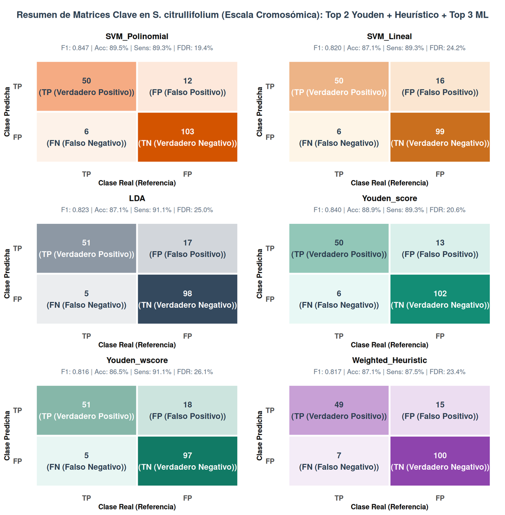

**Resumen Tesis: 9 Modelos Estándar (3x3)**

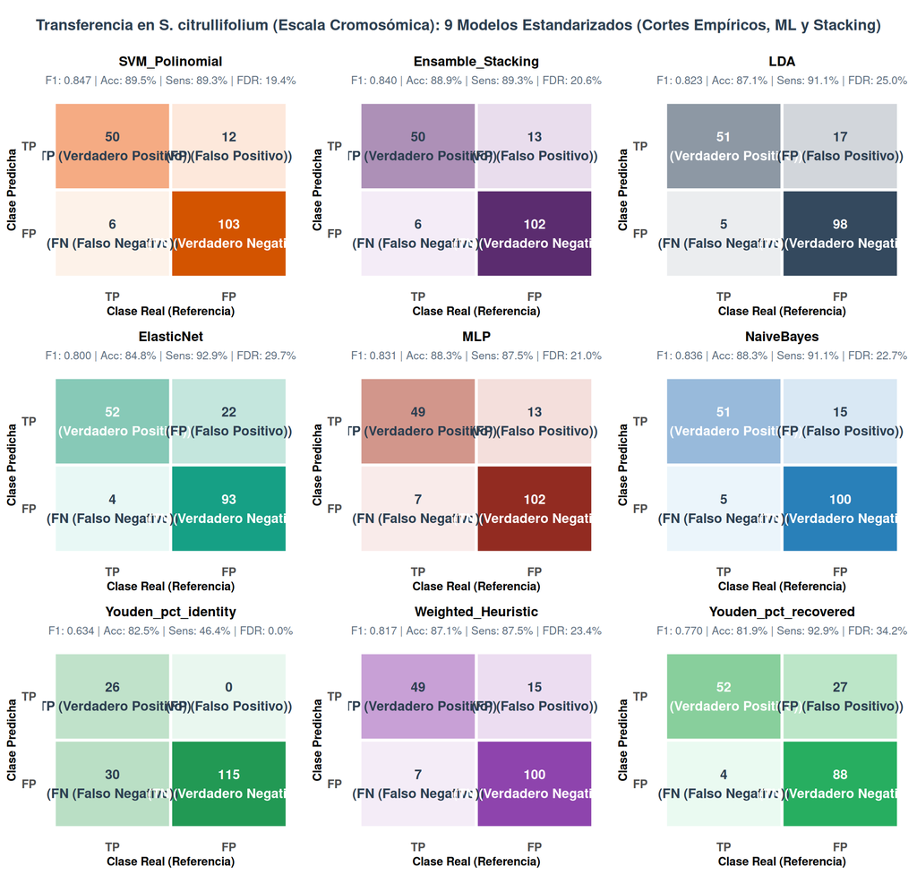

**Top 3 ML Específicos (F1-Score)**

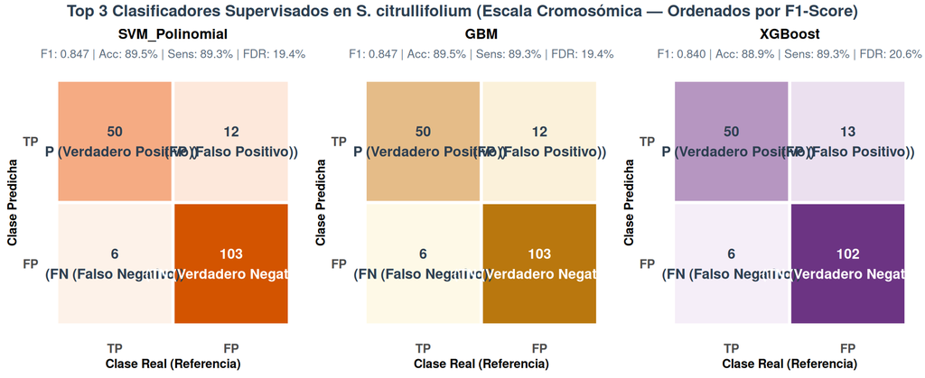

**SVM_Polinomial**

SVM_Polinomial en S. citrullifolium — F1: 0.847 | ROC-AUC: 0.966 | Exactitud: 89.47% | Exactitud Bal.: 89.43% | Sensibilidad: 89.29% | Especificidad: 89.57% | Precisión: 80.65% | FDR: 19.35%

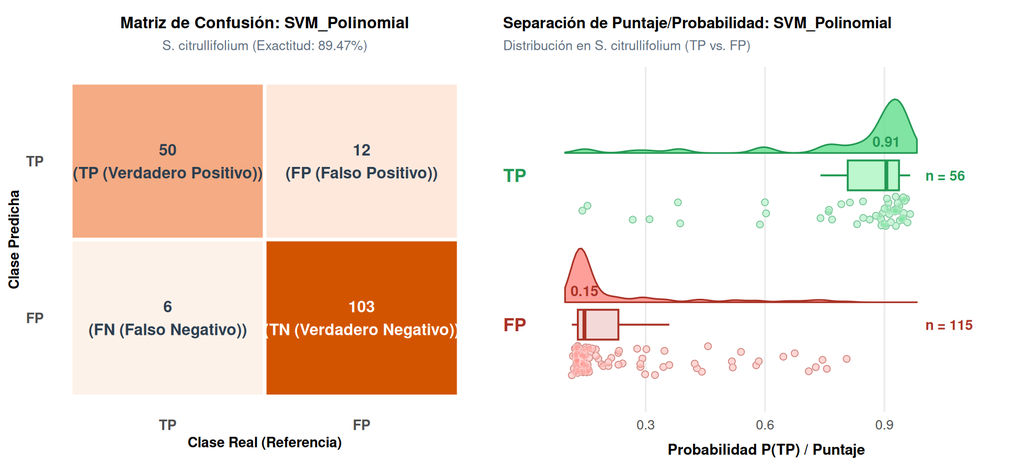

**Ensamble_Stacking**

Ensamble_Stacking en S. citrullifolium — F1: 0.840 | ROC-AUC: 0.966 | Exactitud: 88.89% | Exactitud Bal.: 88.99% | Sensibilidad: 89.29% | Especificidad: 88.70% | Precisión: 79.37% | FDR: 20.63%

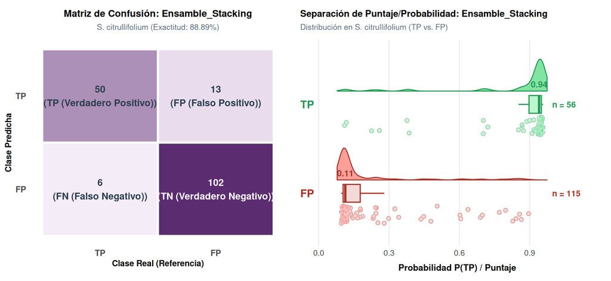

**SVM_Lineal**

SVM_Lineal en S. citrullifolium — F1: 0.820 | ROC-AUC: 0.963 | Exactitud: 87.13% | Exactitud Bal.: 87.69% | Sensibilidad: 89.29% | Especificidad: 86.09% | Precisión: 75.76% | FDR: 24.24%

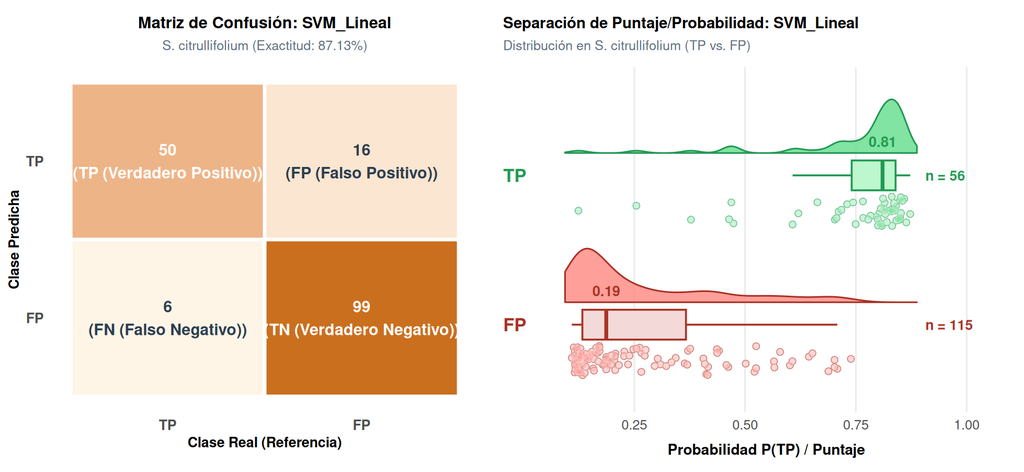

**LDA**

LDA en S. citrullifolium — F1: 0.823 | ROC-AUC: 0.962 | Exactitud: 87.13% | Exactitud Bal.: 88.14% | Sensibilidad: 91.07% | Especificidad: 85.22% | Precisión: 75.00% | FDR: 25.00%

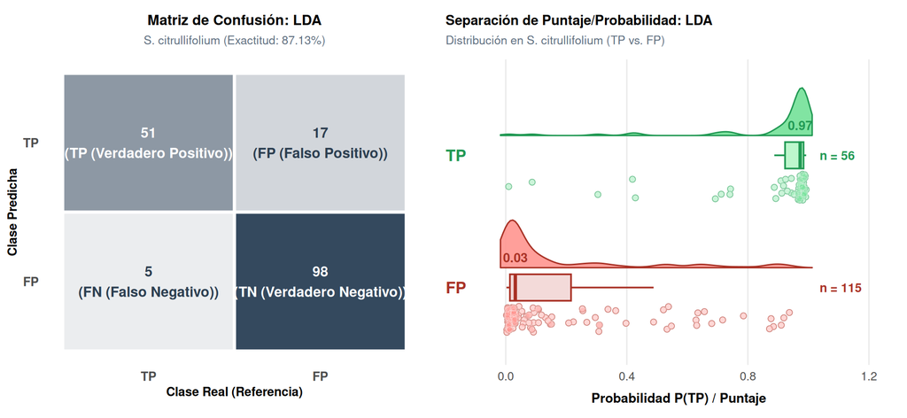

**ElasticNet**

ElasticNet en S. citrullifolium — F1: 0.800 | ROC-AUC: 0.961 | Exactitud: 84.80% | Exactitud Bal.: 86.86% | Sensibilidad: 92.86% | Especificidad: 80.87% | Precisión: 70.27% | FDR: 29.73%

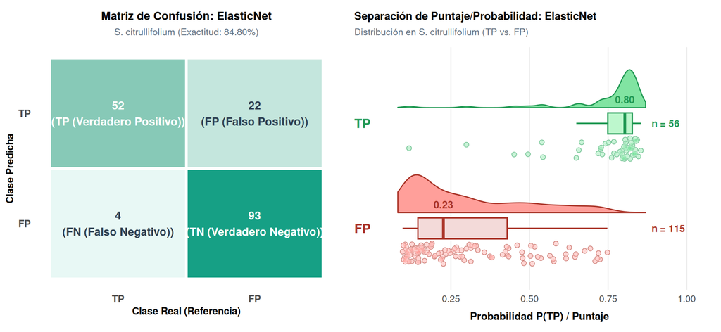

**Red_Neuronal**

Red_Neuronal en S. citrullifolium — F1: 0.832 | ROC-AUC: 0.961 | Exactitud: 87.72% | Exactitud Bal.: 89.04% | Sensibilidad: 92.86% | Especificidad: 85.22% | Precisión: 75.36% | FDR: 24.64%

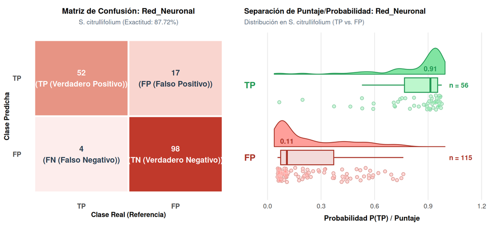

**Youden_score**

Youden_score en S. citrullifolium — F1: 0.840 | ROC-AUC: 0.961 | Exactitud: 88.89% | Exactitud Bal.: 88.99% | Sensibilidad: 89.29% | Especificidad: 88.70% | Precisión: 79.37% | FDR: 20.63%

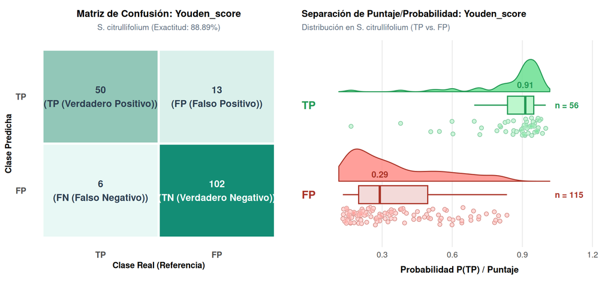

**MLP_Regularizado**

MLP_Regularizado en S. citrullifolium — F1: 0.819 | ROC-AUC: 0.960 | Exactitud: 86.55% | Exactitud Bal.: 88.17% | Sensibilidad: 92.86% | Especificidad: 83.48% | Precisión: 73.24% | FDR: 26.76%

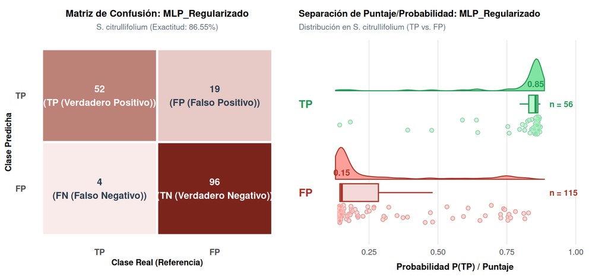

**Red_Neuronal_Bag**

Red_Neuronal_Bag en S. citrullifolium — F1: 0.819 | ROC-AUC: 0.960 | Exactitud: 86.55% | Exactitud Bal.: 88.17% | Sensibilidad: 92.86% | Especificidad: 83.48% | Precisión: 73.24% | FDR: 26.76%

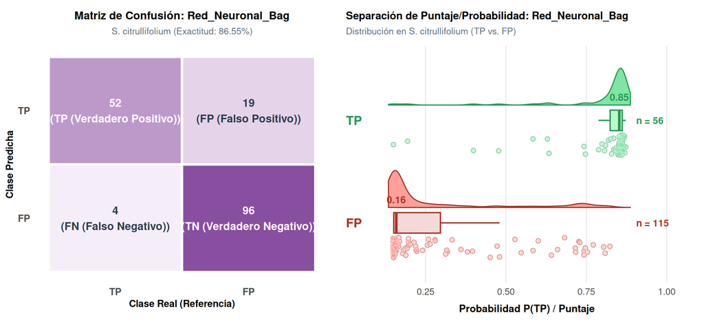

**MLP**

MLP en S. citrullifolium — F1: 0.831 | ROC-AUC: 0.960 | Exactitud: 88.30% | Exactitud Bal.: 88.10% | Sensibilidad: 87.50% | Especificidad: 88.70% | Precisión: 79.03% | FDR: 20.97%

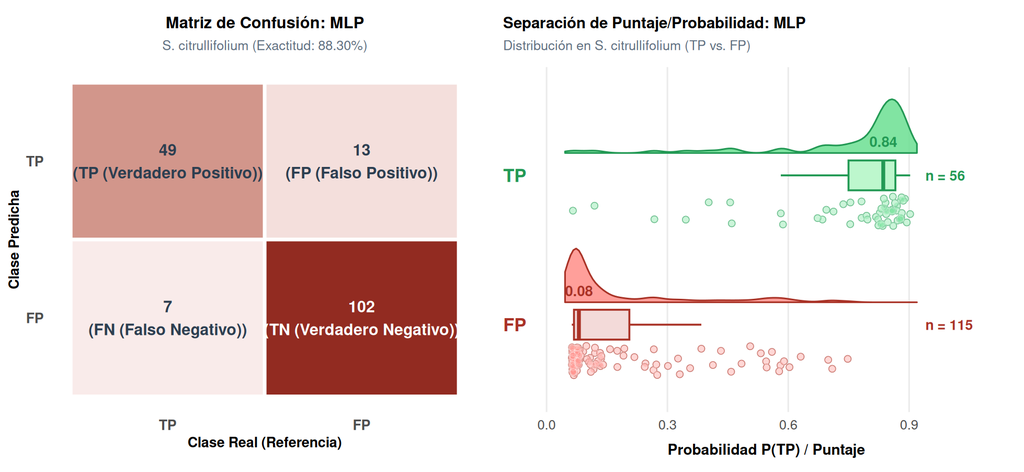

**NaiveBayes**

NaiveBayes en S. citrullifolium — F1: 0.836 | ROC-AUC: 0.960 | Exactitud: 88.30% | Exactitud Bal.: 89.01% | Sensibilidad: 91.07% | Especificidad: 86.96% | Precisión: 77.27% | FDR: 22.73%

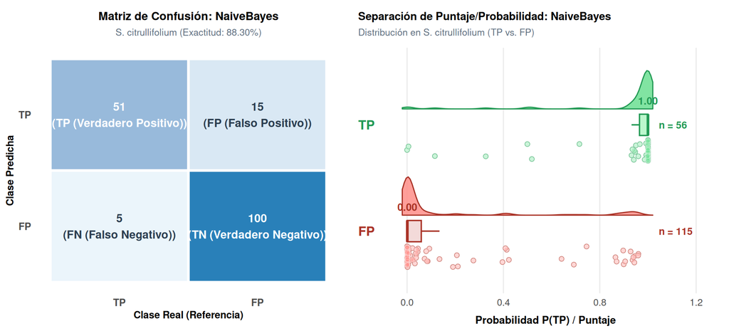

**Youden_wscore**

Youden_wscore en S. citrullifolium — F1: 0.816 | ROC-AUC: 0.959 | Exactitud: 86.55% | Exactitud Bal.: 87.71% | Sensibilidad: 91.07% | Especificidad: 84.35% | Precisión: 73.91% | FDR: 26.09%

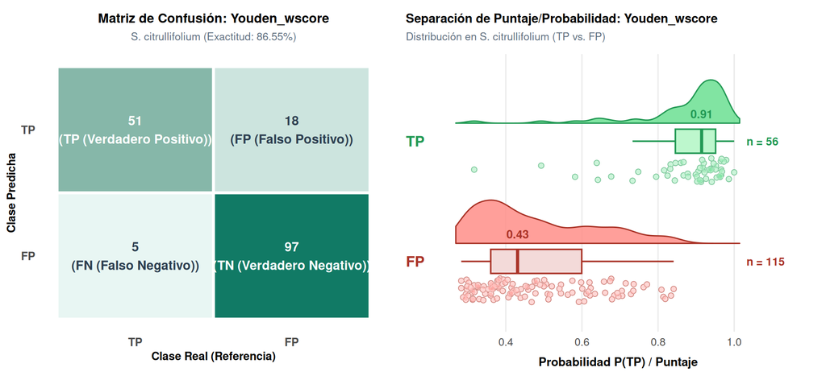

**GBM**

GBM en S. citrullifolium — F1: 0.847 | ROC-AUC: 0.958 | Exactitud: 89.47% | Exactitud Bal.: 89.43% | Sensibilidad: 89.29% | Especificidad: 89.57% | Precisión: 80.65% | FDR: 19.35%

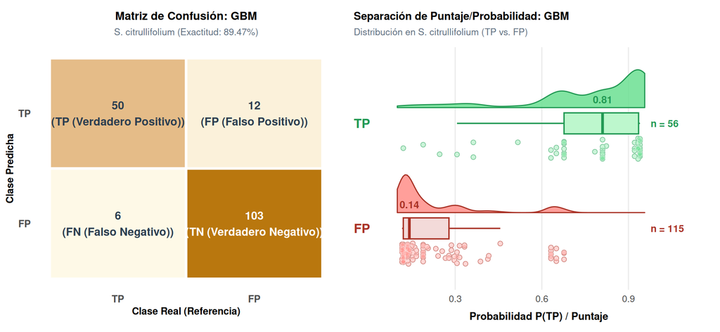

**KNN**

KNN en S. citrullifolium — F1: 0.800 | ROC-AUC: 0.954 | Exactitud: 85.38% | Exactitud Bal.: 86.38% | Sensibilidad: 89.29% | Especificidad: 83.48% | Precisión: 72.46% | FDR: 27.54%

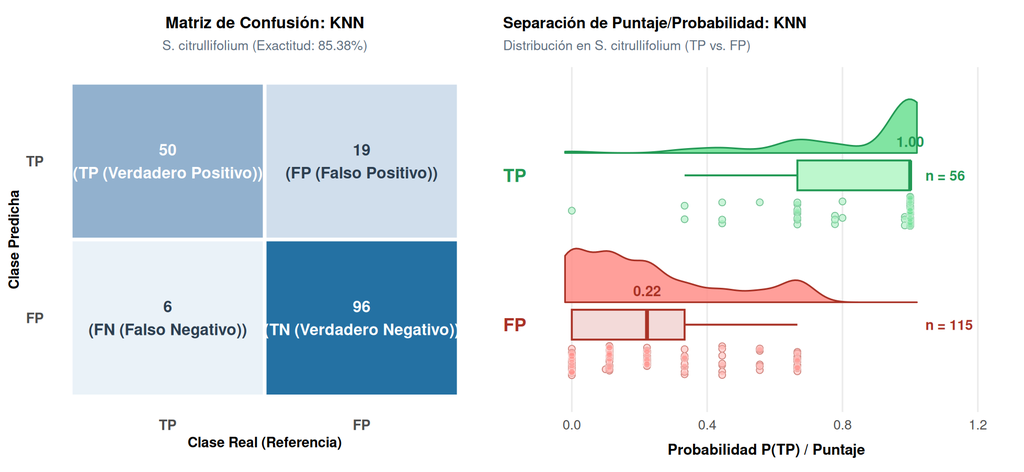

**Youden_pct_identity**

Youden_pct_identity en S. citrullifolium — F1: 0.634 | ROC-AUC: 0.942 | Exactitud: 82.46% | Exactitud Bal.: 73.21% | Sensibilidad: 46.43% | Especificidad: 100.00% | Precisión: 100.00% | FDR: 0.00%

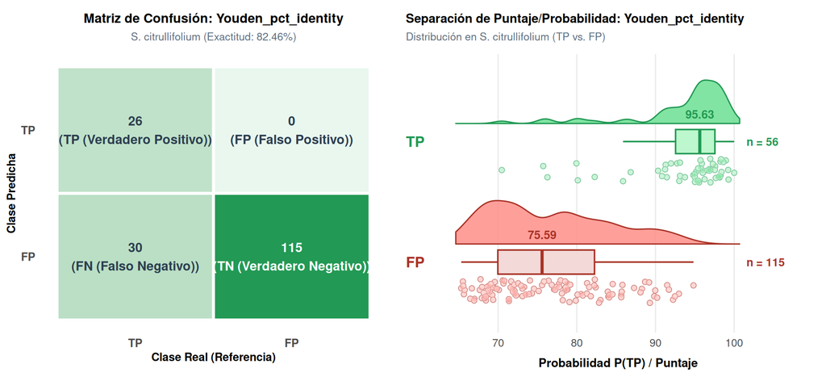

**RandomForest**

RandomForest en S. citrullifolium — F1: 0.807 | ROC-AUC: 0.940 | Exactitud: 86.55% | Exactitud Bal.: 86.34% | Sensibilidad: 85.71% | Especificidad: 86.96% | Precisión: 76.19% | FDR: 23.81%

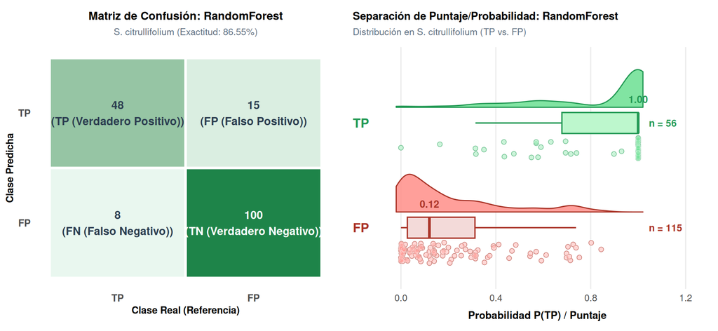

**Consenso_7_Modelos**

Consenso_7_Modelos en S. citrullifolium — F1: 0.836 | ROC-AUC: 0.934 | Exactitud: 88.30% | Exactitud Bal.: 89.01% | Sensibilidad: 91.07% | Especificidad: 86.96% | Precisión: 77.27% | FDR: 22.73%

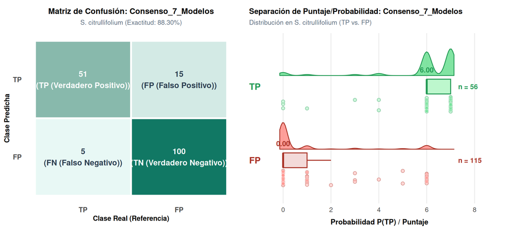

**Weighted_Heuristic**

Weighted_Heuristic en S. citrullifolium — F1: 0.817 | ROC-AUC: 0.933 | Exactitud: 87.13% | Exactitud Bal.: 87.23% | Sensibilidad: 87.50% | Especificidad: 86.96% | Precisión: 76.56% | FDR: 23.44%

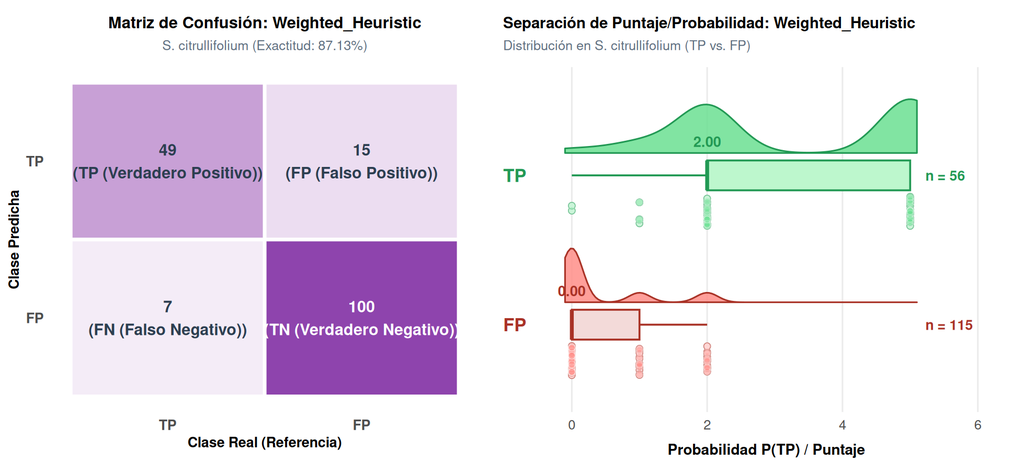

**SVM_Radial**

SVM_Radial en S. citrullifolium — F1: 0.825 | ROC-AUC: 0.929 | Exactitud: 87.13% | Exactitud Bal.: 88.60% | Sensibilidad: 92.86% | Especificidad: 84.35% | Precisión: 74.29% | FDR: 25.71%

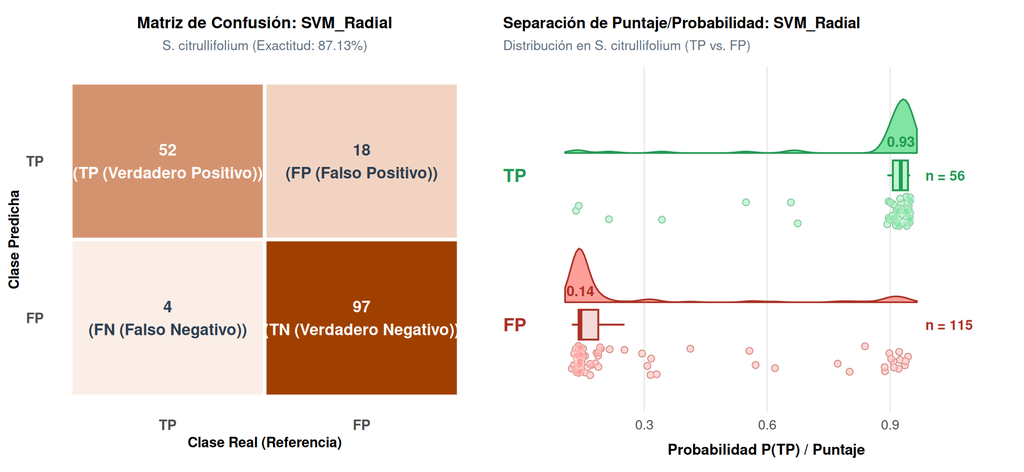

**XGBoost**

XGBoost en S. citrullifolium — F1: 0.840 | ROC-AUC: 0.923 | Exactitud: 88.89% | Exactitud Bal.: 88.99% | Sensibilidad: 89.29% | Especificidad: 88.70% | Precisión: 79.37% | FDR: 20.63%

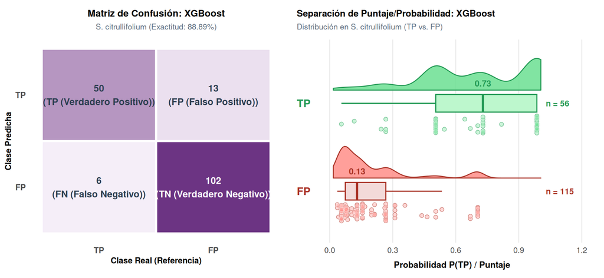

**CART**

CART en S. citrullifolium — F1: 0.794 | ROC-AUC: 0.911 | Exactitud: 84.80% | Exactitud Bal.: 85.95% | Sensibilidad: 89.29% | Especificidad: 82.61% | Precisión: 71.43% | FDR: 28.57%

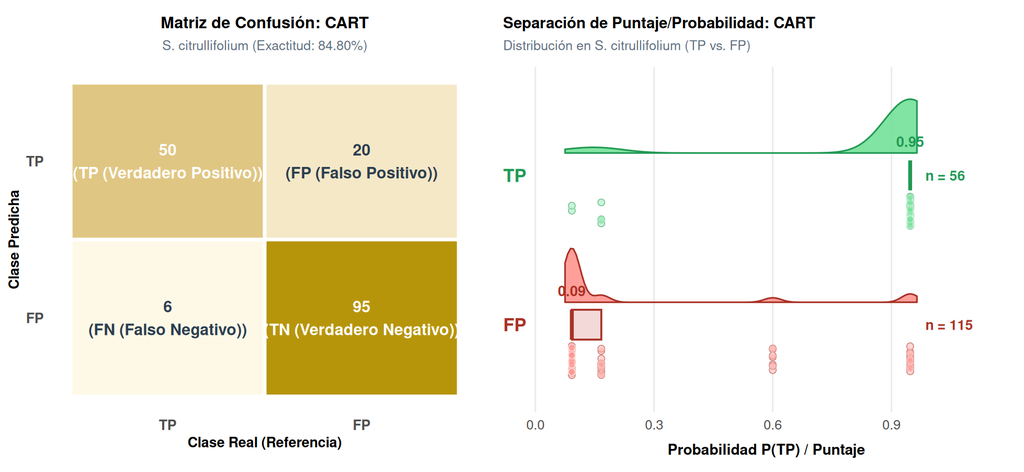

**Youden_pct_recovered**

Youden_pct_recovered en S. citrullifolium — F1: 0.770 | ROC-AUC: 0.906 | Exactitud: 81.87% | Exactitud Bal.: 84.69% | Sensibilidad: 92.86% | Especificidad: 76.52% | Precisión: 65.82% | FDR: 34.18%

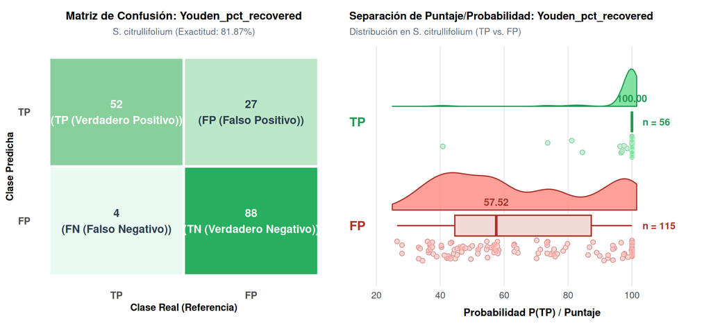

**QDA**

QDA en S. citrullifolium — F1: 0.756 | ROC-AUC: 0.905 | Exactitud: 83.04% | Exactitud Bal.: 82.35% | Sensibilidad: 80.36% | Especificidad: 84.35% | Precisión: 71.43% | FDR: 28.57%

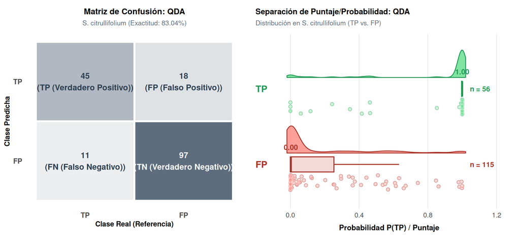

**Bagging_Arboles**

Bagging_Arboles en S. citrullifolium — F1: 0.646 | ROC-AUC: 0.875 | Exactitud: 80.12% | Exactitud Bal.: 73.77% | Sensibilidad: 55.36% | Especificidad: 92.17% | Precisión: 77.50% | FDR: 22.50%

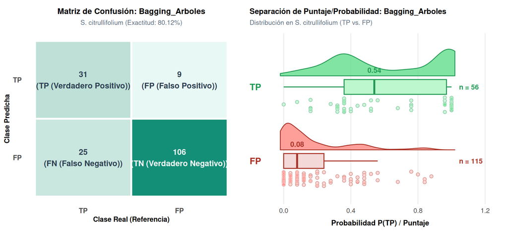

**Stacked Autoencoder - DNN**

Stacked Autoencoder - DNN en S. citrullifolium — F1: 0.493 | ROC-AUC: 0.071 | Exactitud: 32.75% | Exactitud Bal.: 50.00% | Sensibilidad: 100.00% | Especificidad: 0.00% | Precisión: 32.75% | FDR: 67.25%

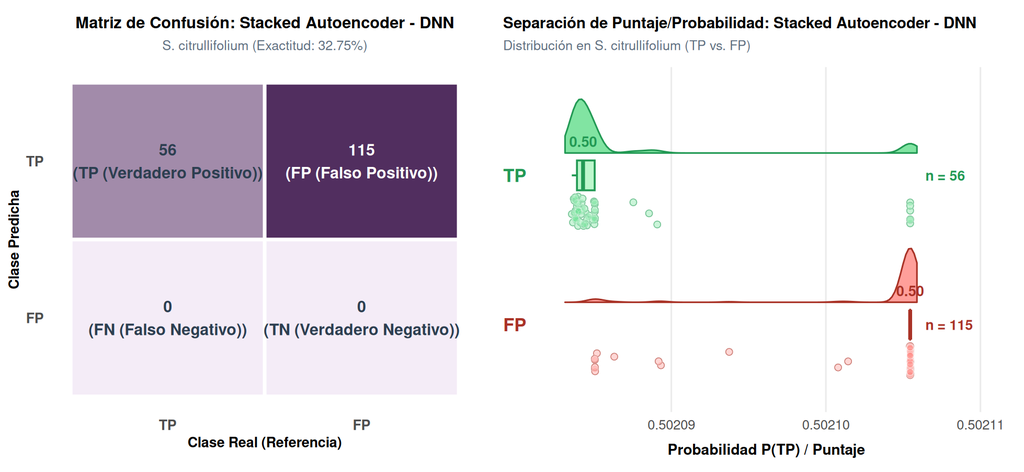

**S. stellatiglandulosum (Escala de Contigs)**

Escala de Contigs **Especie Validada:** *Solanum stellatiglandulosum* (Muestra: `S_stella`)  
**Fuente del Genoma de Referencia:** Reportado en NCBI BioProject (https://www.ncbi.nlm.nih.gov/bioproject/?term=txid3132602%5BOrganism:noexp%5D) con Accession: PRJNA1070281, ID: 1070281 por el Grupo de Genómica Evolutiva del Metabolismo Especializado de la Universidad Nacional de Colombia.  
**Fuente de Homología y Datos Génicos:** Pérez-Mesa, P. A. & Roda, F.: , 2025; Alkaloid evolution in the solanaceae; Current Opinion in Plant Biology; 85: 102727; [doi:10.1016/j.pbi.2025.102727](https://doi.org/10.1016/j.pbi.2025.102727) | Pérez-Mesa, P. A.; Pardo, R. A.; Alseekh, S. et al.: , 2026; Genetic basis of alkaloid divergence in the solanaceae; Plant Molecular Biology; 116: 67; [doi:10.1007/s11103-026-01718-6](https://doi.org/10.1007/s11103-026-01718-6) (Homología jerárquica HOG_ID reconciliada mediante Tabla Puente OG_ID <-> HOG_ID). | Cobertura Tabla Puente OG_ID <-> HOG_ID: **19 de 33 OGs**  
**Archivo de Origen:** `data_prepared.rds`  
**Estrategia de Validación Espacial:** Extracción directa de identificadores génicos desde el atributo Target de Scipio/CAPTUS, reconciliación de grupos jerárquicos HOG_ID con ortogrupos pangenómicos OG_ID mediante la tabla puente del diseño de sondas y deduplicación intra-locus.

Secuencias NUC Evaluadas

200

Muestra S_stella

Verdaderos Positivos (TP)

19 (9.5%)

Homólogos validados

Falsos Positivos (FP)

181 (90.5%)

Ruido o redundancia

Escala del Ensamblaje

Escala de Contigs

Modo: target_attr + Puente OG/HOG

### 2.4 Resumen de Secuencias Evaluadas (TP vs. FP) en *S. stellatiglandulosum*

| Clase | Secuencias | Porcentaje | Media % Recuperado | Media % Identidad | Media Score | Media WScore |
| --- | --- | --- | --- | --- | --- | --- |
| TP (Verdadero Positivo) | 19 | 9.5 | 100 | 99.13 | 0.98 | 0.98 |
| FP (Falso Positivo) | 181 | 90.5 | 72.27 | 81.5 | 0.49 | 0.58 |

### 2.5 Benchmark Multimétrica de Transferencia en *S. stellatiglandulosum*

[interactive chart not shown]

**Ver Benchmark de los 9 Modelos Estandarizados (S. stellatiglandulosum)**

[interactive chart not shown]

**Ver Benchmark de Todos los Modelos Evaluados (S. stellatiglandulosum)**

[interactive chart not shown]

**Ver Tabla Completa de Métricas**

Los modelos marcados con `*` logran menor FDR o mayor índice global al transferirse desde su versión entrenada en el escenario desbalanceado de *S. torvum*.

| Modelo | Mejor_Version_FDR | Exactitud | Exactitud_Balanceada | Sensibilidad | Especificidad | Precision | VPN | FDR | F1_Score | MCC | Kappa | ROC_AUC | TP | FP | FN | TN |
| --- | --- | --- | --- | --- | --- | --- | --- | --- | --- | --- | --- | --- | --- | --- | --- | --- |
| SVM_Radial * | * Mejor en Desbalanceado (FDR: 72.06% vs 76.25% \| Índice: 0.459 vs 0.420) | 69.5 | 83.15 | 100 | 66.3 | 23.75 | 100 | 76.25 | 0.384 | 0.397 | 0.272 | 0.932 | 19 | 61 | 0 | 120 |
| GBM | Óptimo en Balanceado (FDR: 74.32% vs 75.00% \| Índice: 0.437 vs 0.430) | 72.5 | 84.81 | 100 | 69.61 | 25.68 | 100 | 74.32 | 0.409 | 0.423 | 0.303 | 0.914 | 19 | 55 | 0 | 126 |
| Youden_pct_identity | Invariante (regla fija) | 80.5 | 89.23 | 100 | 78.45 | 32.76 | 100 | 67.24 | 0.494 | 0.507 | 0.409 | 0.913 | 19 | 39 | 0 | 142 |
| Youden_score | Invariante (regla fija) | 72 | 84.53 | 100 | 69.06 | 25.33 | 100 | 74.67 | 0.404 | 0.418 | 0.298 | 0.913 | 19 | 56 | 0 | 125 |
| Youden_wscore | Invariante (regla fija) | 72.5 | 84.81 | 100 | 69.61 | 25.68 | 100 | 74.32 | 0.409 | 0.423 | 0.303 | 0.913 | 19 | 55 | 0 | 126 |
| NaiveBayes * | * Mejor en Desbalanceado (FDR: 75.32% vs 75.64% \| Índice: 0.427 vs 0.424) | 70.5 | 83.7 | 100 | 67.4 | 24.36 | 100 | 75.64 | 0.392 | 0.405 | 0.282 | 0.913 | 19 | 59 | 0 | 122 |
| SVM_Polinomial | Óptimo en Balanceado (FDR: 72.46% vs 82.08% \| Índice: 0.455 vs 0.354) | 75 | 86.19 | 100 | 72.38 | 27.54 | 100 | 72.46 | 0.432 | 0.446 | 0.332 | 0.912 | 19 | 50 | 0 | 131 |
| Ensamble_Stacking | Óptimo en Balanceado (FDR: 73.61% vs 76.25% \| Índice: 0.444 vs 0.418) | 73.5 | 85.36 | 100 | 70.72 | 26.39 | 100 | 73.61 | 0.418 | 0.432 | 0.315 | 0.912 | 19 | 53 | 0 | 128 |
| Red_Neuronal | Óptimo en Balanceado (FDR: 75.64% vs 75.95% \| Índice: 0.424 vs 0.418) | 70.5 | 83.7 | 100 | 67.4 | 24.36 | 100 | 75.64 | 0.392 | 0.405 | 0.282 | 0.912 | 19 | 59 | 0 | 122 |
| ElasticNet * | * Mejor en Desbalanceado (FDR: 77.11% vs 77.38% \| Índice: 0.409 vs 0.406) | 67.5 | 82.04 | 100 | 64.09 | 22.62 | 100 | 77.38 | 0.369 | 0.381 | 0.253 | 0.912 | 19 | 65 | 0 | 116 |

[output cut: 15 more lines]

### 2.6 Matrices de Confusión y Distribución de Puntajes (*S. stellatiglandulosum*)

**Resumen: Top 6 (2 Youden + Heurístico + 3 ML)**

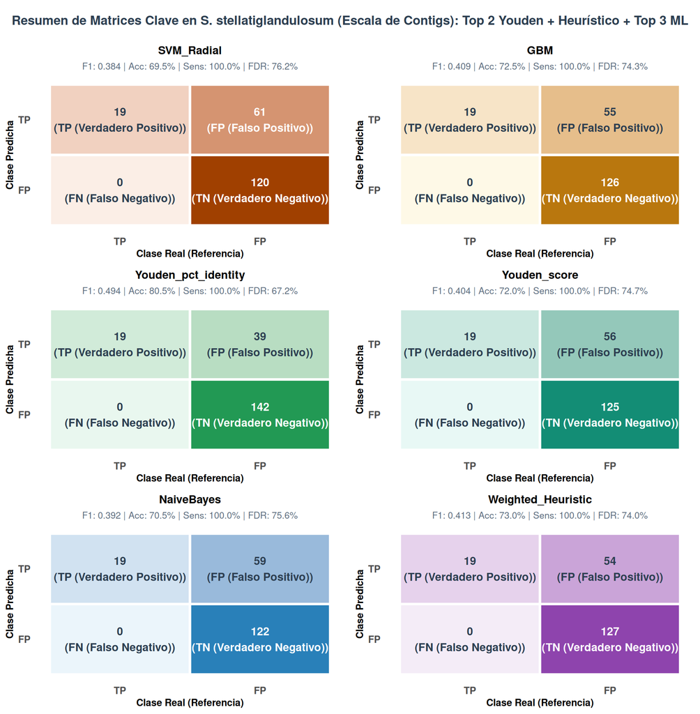

**Resumen Tesis: 9 Modelos Estándar (3x3)**

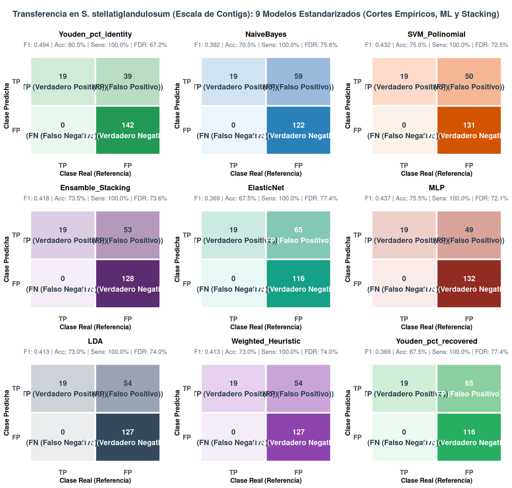

**Top 3 ML Específicos (F1-Score)**

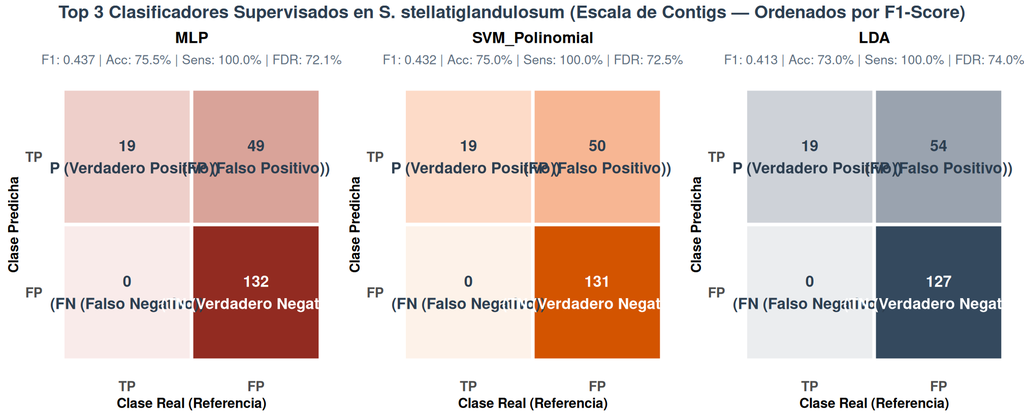

**SVM_Radial**

SVM_Radial en S. stellatiglandulosum — F1: 0.384 | ROC-AUC: 0.932 | Exactitud: 69.50% | Exactitud Bal.: 83.15% | Sensibilidad: 100.00% | Especificidad: 66.30% | Precisión: 23.75% | FDR: 76.25%

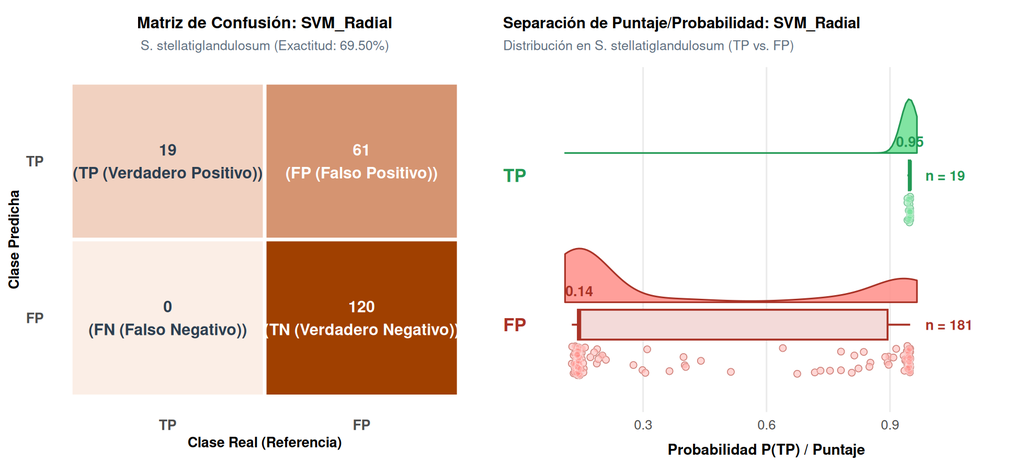

**GBM**